# Data Analysis of Coffee Orders

Spencer Reinsfield - srei868

## Using R Studio to Analyse Coffee Order Data

For this visual data story, I went the University of Auckland’s Ora Cafe at the Recreation Centre and observed coffee orders. I observed different aspects of coffee orders such the name of the drink, the temperature of the drink, the time it took to make the drink, etc.

I was the only person involved in the data collection process.

I wanted this project to focus on how my data can benefit customers at the University of Auckland’s Ora Cafe. I first wondered what the most popular drink at the Ora Cafe is.

## What is the most common Ora Cafe Order?

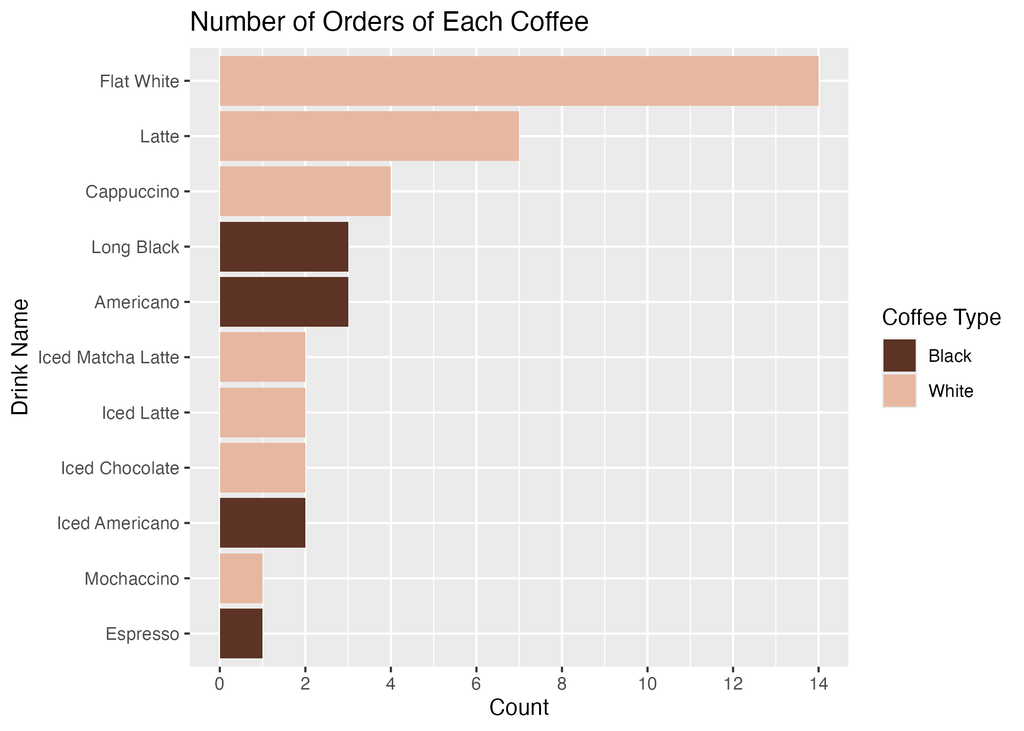

It turns out that the most popular order at the Ora Cafe is the Flat White. I observed this order 14 times during the data collection process. With 7 observed orders, the Latte is also popular.

I also noticed white coffees are significantly more popular than black coffees. Customers would find this information useful because the popularity of white coffees can affect the time it takes for their order to be completed because would need to froth the milk - a process that takes much longer than pouring hot water with an espresso.

However, frothing is only necessary for hot white coffees, and I would expect hot coffees to be more popular during colder time periods like winter, so I wondered how the whether the month of the year affects the time it takes to complete an order.

## Does the Month the Data was Recorded Affect the Time it takes to Complete an Order

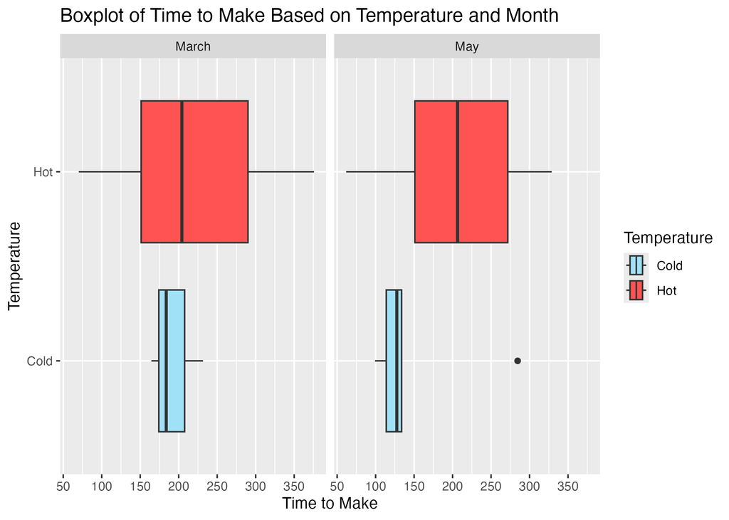

From here, I was interested in how the average time it takes to complete a coffee order compares between all the observed drinks. I was certain customers would be interested in what the average time it takes to complete their favourite coffee order takes.

## What is the Mean Time it takes to Complete an Order for Each Drink?

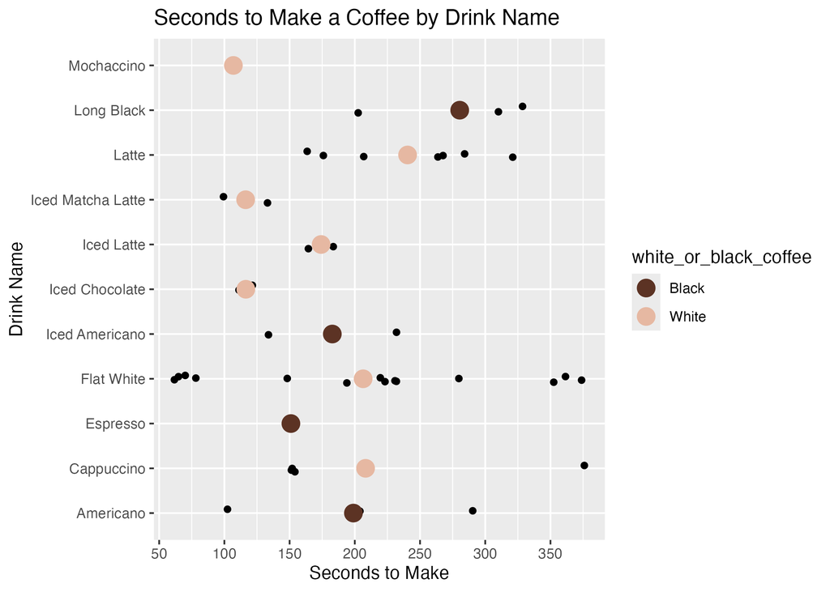

The average time for each drink is labelled with a large dot that is coloured in either light brown if it’s a white coffee, and dark brown if it’s a black coffee.

It is important to bare in mind that the sample size each drink is very small, so the average time it takes to complete for each drink is likely to be bias. Although this is true, knowing the average time it takes to complete for each drink made me wonder what drinks would have the longest average time to make.

## What Coffees have the Longest Average Time to Make?

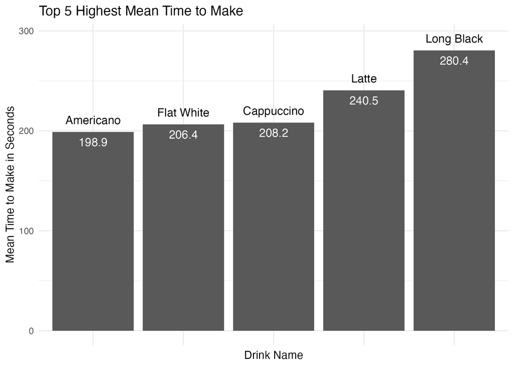

Out of all the drinks that were observed, the 5 longest average time to to complete were Americano, Flat White, Cappuccino, Latte, and Long Black.

What I find interesting about this is that the Long Black and Americano are in the top 5 longest average time to make. I did not expect this because these drinks only require an espresso and hot water - a much easier drink to make than those that require frothing milk.

Overall, this data analysis project was successful.